# ES114 PSDV Prerequisite test

## 8)Create a list of tuples, where each tuple contains a number and its square (e.g., [(1, 1), (2, 4), (3, 9), ...] for numbers 1 to 10).

```
Plot the numbers and their squares on a scatter plot.
```

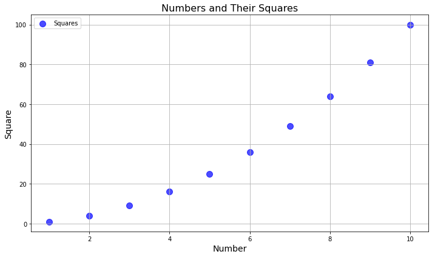

```python
import matplotlib.pyplot as plt
numbers_and_squares = [(i, i**2) for i in range(1, 11)]
numbers, squares = zip(*numbers_and_squares)
plt.figure(figsize=(10, 6))
plt.scatter(numbers, squares, color='blue', s=100, label='Squares', alpha=0.7)  # Scatter plot

plt.title('Numbers and Their Squares', fontsize=16)
plt.xlabel('Number', fontsize=14)
plt.ylabel('Square', fontsize=14)


plt.grid(True)


plt.legend()


plt.tight_layout()
plt.show()
```

## 9)Write Python code to merge two dictionaries. If a key is present in both, sum their values.

Example:

dict1 = {'a': 10, 'b': 20} dict2 = {'b': 5, 'c': 15} Output: {'a': 10, 'b': 25, 'c': 15}

```python
dict1 = {'a': 10, 'b': 20}
dict2 = {'b': 5, 'c': 15}

merged_dict = dict1.copy()

for key, value in dict2.items():
    if key in merged_dict:
        merged_dict[key] += value
    else:
        merged_dict[key] = value

print(merged_dict)
```

```
{'a': 10, 'b': 25, 'c': 15}
```

## 10) Write a function that accepts a string and:

```
Converts all characters to lowercase.
Counts the frequency of each character.
Returns a dictionary with characters as keys and their counts as values.
Visualize the character frequencies using a bar chart.
```

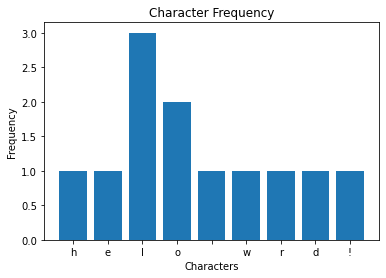

```
{'h': 1, 'e': 1, 'l': 3, 'o': 2, ' ': 1, 'w': 1, 'r': 1, 'd': 1, '!': 1}
```

```python
import matplotlib.pyplot as plt

def puton(input_string):
    input_string = input_string.lower()
    frequency = {}
    for char in input_string:
        if char in frequency:
            frequency[char] += 1
        else:
            frequency[char] = 1


    plt.bar(frequency.keys(), frequency.values())
    plt.xlabel('Characters')
    plt.ylabel('Frequency')
    plt.title('Character Frequency')
    plt.show()

    return frequency


result = puton("Hello World!")
print(result)
```

## 11) Write a program to remove duplicate elements from a list while maintaining the order of elements.

```
Calculate the mean and median of the unique elements.
```

```python
from statistics import mean, median

def remove_duplicates_and_calculate_stats(input_list):
    unique_list = []
    for item in input_list:
        if item not in unique_list:
            unique_list.append(item)

    if unique_list:
        calculated_mean = mean(unique_list)
        calculated_median = median(unique_list)
    else:
        calculated_mean = None
        calculated_median = None

    return unique_list, calculated_mean, calculated_median


input_data = [5, 3, 8, 3, 5, 10, 8, 1]
unique_elements, calculated_mean, calculated_median = remove_duplicates_and_calculate_stats(input_data)

print("Unique Elements:", unique_elements)
print("Mean of Unique Elements:", calculated_mean)
print("Median of Unique Elements:", calculated_median)
```

```
Unique Elements: [5, 3, 8, 10, 1]
Mean of Unique Elements: 5.4
Median of Unique Elements: 5
```

## 12) Given a list of strings, write a Python function to:

```
Find the longest string.
Count how many strings start with a vowel.
Visualize the distribution of string lengths using a histogram.
```

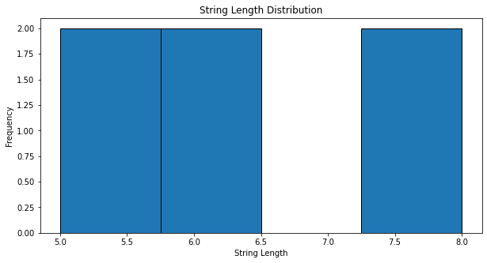

```
{'longest_string': 'elephant', 'vowel_start_count': 5, 'max_length': 8}
```

```python
import matplotlib.pyplot as plt

def analyze_strings(string_list):
    longest_string = max(string_list, key=len, default='')

    vowel_count = sum(1 for s in string_list if s and s[0].lower() in 'aeiou')
    lengths = [len(s) for s in string_list]
    plt.figure(figsize=(10, 5))
    plt.hist(lengths, bins='auto', edgecolor='black')
    plt.title('String Length Distribution')
    plt.xlabel('String Length')
    plt.ylabel('Frequency')
    plt.show()

    return {
        'longest_string': longest_string,
        'vowel_start_count': vowel_count,
        'max_length': len(longest_string)
    }

sample_list = ['apple', 'banana', 'elephant', 'igloo', 'orange', 'umbrella']
result = analyze_strings(sample_list)
print(result)
```

## 13. Write a function to sort a list of dictionaries by a key.

```
   - Example:
     - data = [{'name': 'Alice', 'age': 25}, {'name': 'Bob', 'age': 22}]
     - Sort by age → [{'name': 'Bob', 'age': 22}, {'name': 'Alice', 'age': 25}]
```

```python
def sort_dict_list(data, key, reverse=False):

    return sorted(data, key=lambda x: x[key], reverse=reverse)


data = [
    {'name': 'Anu', 'age': 25},
    {'name': 'Dia', 'age': 22},
    {'name': 'Dev', 'age': 30}
]

# Sort by age (ascending)
sorted_by_age = sort_dict_list(data, 'age')
print(sorted_by_age)

# Sort by age (descending)
sorted_by_age_desc = sort_dict_list(data, 'age', reverse=True)
print(sorted_by_age_desc)

# Sort by name
sorted_by_name = sort_dict_list(data, 'name')
print(sorted_by_name)
```

```
[{'name': 'Dia', 'age': 22}, {'name': 'Anu', 'age': 25}, {'name': 'Dev', 'age': 30}]
[{'name': 'Dev', 'age': 30}, {'name': 'Anu', 'age': 25}, {'name': 'Dia', 'age': 22}]
[{'name': 'Anu', 'age': 25}, {'name': 'Dev', 'age': 30}, {'name': 'Dia', 'age': 22}]
```

## 14) Write a program to:

```
Split a string into a list of words.
Remove all words that are shorter than 4 characters.
Sort the remaining words alphabetically.
Visualize the word lengths using a bar chart.
```

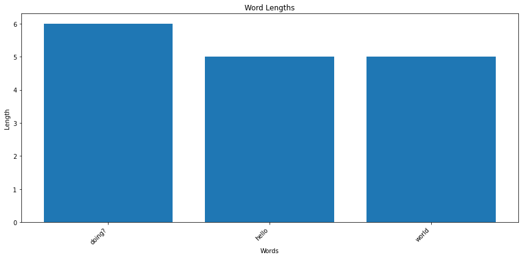

```
{'filtered_words': ['doing?', 'hello', 'world'], 'word_count': 3}
```

```python
import matplotlib.pyplot as plt

def process_text(text):
    words = text.split()
    filtered_words = [word for word in words if len(word) >= 4]
    sorted_words = sorted(filtered_words)

    plt.figure(figsize=(12, 6))
    word_lengths = [len(word) for word in sorted_words]

    plt.bar(sorted_words, word_lengths)
    plt.title('Word Lengths')
    plt.xlabel('Words')
    plt.ylabel('Length')
    plt.xticks(rotation=45, ha='right')
    plt.tight_layout()
    plt.show()

    return {
        'filtered_words': sorted_words,
        'word_count': len(sorted_words)
    }

sample_text = "hello world how are you doing?"
result = process_text(sample_text)
print(result)
```

## 15)Write a Python function to find all anagrams of a word in a given list.

```
Input: word = "listen", words = ["enlist", "google", "inlets", "banana"]
Output: ["enlist", "inlets"]
```

```python
def anagramfinder(word, words):
    sorted_word = sorted(word)
    return [w for w in words if sorted(w) == sorted_word]

word = "listen"
words = ["enlist", "google", "inlets", "banana"]
anagrams = anagramfinder(word, words)
print(anagrams)  # Output: ["enlist", "inlets"]
```

```
['enlist', 'inlets']
```

## 16)Given two lists, write Python code to find their intersection, union, and symmetric difference.

```
Visualize the results using Venn diagrams
```

```
Intersection: {4, 5}
Union: {1, 2, 3, 4, 5, 6, 7, 8}
Symmetric Difference: {1, 2, 3, 6, 7, 8}
{'set1': {1, 2, 3, 4, 5}, 'set2': {4, 5, 6, 7, 8}, 'intersection': {4, 5}, 'union': {1, 2, 3, 4, 5, 6, 7, 8}, 'symmetric_difference': {1, 2, 3, 6, 7, 8}}
```

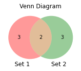

```python
import matplotlib.pyplot as plt
from matplotlib_venn import venn2
import numpy as np

def set_operations_visualization(list1, list2, title='Set Operations'):

    # Convert lists to sets
    set1 = set(list1)
    set2 = set(list2)

    # Compute set operations
    intersection = set1 & set2
    union = set1 | set2
    symmetric_difference = set1 ^ set2

    # Print set operations
    print(f"Intersection: {intersection}")
    print(f"Union: {union}")
    print(f"Symmetric Difference: {symmetric_difference}")

    #

    #  Venn Diagram
    plt.subplot(121)
    venn2([set1, set2], set_labels=('Set 1', 'Set 2'))
    plt.title('Venn Diagram')



    return {
        'set1': set1,
        'set2': set2,
        'intersection': intersection,
        'union': union,
        'symmetric_difference': symmetric_difference
    }

# Example usage
list1 = [1, 2, 3, 4, 5]
list2 = [4, 5, 6, 7, 8]

result = set_operations_visualization(list1, list2, 'Advanced Set Operations')
print(result)
```

## 17)Write Python code to:

```
Create a text file.
Write a list of numbers to the file (one per line).
Read the file and compute their sum.
```

```python
numbers_to_write = [1, 2, 3, 4, 5, 6, 7, 8, 9, 10]


with open('numbers.txt', 'w') as file:
    for number in numbers_to_write:
        file.write(f"{number}\n")


with open('numbers.txt', 'r') as file:
    numbers_from_file = [int(line.strip()) for line in file]

sum_of_numbers = sum(numbers_from_file)
print(f"Sum of numbers from file: {sum_of_numbers}")
```

```
Sum of numbers from file: 55
```

## 18) Write a program to:

```
    Read a file and count the number of words in it.
    Find the most frequent word.
    Visualize the word frequencies using a bar chart.
```

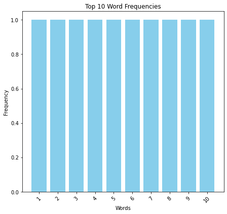

```
{'total_words': 10, 'unique_words': 10, 'most_frequent_word': ('1', 1), 'word_frequencies': {'1': 1, '2': 1, '3': 1, '4': 1, '5': 1, '6': 1, '7': 1, '8': 1, '9': 1, '10': 1}}
```

```python
import matplotlib.pyplot as plt
from collections import Counter
import re

def analyze_text_file(file_path):

    try:

        with open(file_path, 'r', encoding='utf-8') as file:
            text = file.read().lower()


        words = re.findall(r'\b\w+\b', text)


        word_counts = Counter(words)


        top_words = word_counts.most_common(10)

        # Visualization
        plt.figure(figsize=(12, 6))

        # Bar chart of word frequencies
        plt.subplot(121)
        words, frequencies = zip(*top_words)
        plt.bar(words, frequencies, color='skyblue')
        plt.title('Top 10 Word Frequencies')
        plt.xlabel('Words')
        plt.ylabel('Frequency')
        plt.xticks(rotation=45)



        plt.tight_layout()
        plt.show()

        # Return analysis results
        return {
            'total_words': len(words),
            'unique_words': len(set(words)),
            'most_frequent_word': word_counts.most_common(1)[0],
            'word_frequencies': dict(top_words)
        }

    except FileNotFoundError:
        print(f"File not found: {file_path}")
        return None
    except Exception as e:
        print(f"Error processing file: {e}")
        return None

# Example usage
file_path = 'numbers.txt'
result = analyze_text_file(file_path)
print(result)
```

## 19)Write a Python program to:

```
Generate 100 random integers between 1 and 50.
Save them in a text file, one per line.
Read the file and compute the mean of the numbers.
Visualize the distribution of the numbers using a histogram.
```

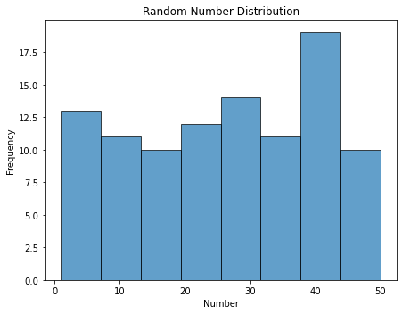

[output not shown]

```python
import random
import numpy as np
import matplotlib.pyplot as plt

def random_number_analysis(count=100, min_val=1, max_val=50):


    random_numbers = [random.randint(min_val, max_val) for _ in range(count)]


    output_file = 'random_numbers.txt'
    with open(output_file, 'w') as file:
        file.write('\n'.join(map(str, random_numbers)))


    with open(output_file, 'r') as file:
        file_numbers = [int(line.strip()) for line in file]


    mean_value = np.mean(file_numbers)
    median_value = np.median(file_numbers)
    std_dev = np.std(file_numbers)


    plt.figure(figsize=(12, 5))


    plt.subplot(121)
    plt.hist(file_numbers, bins='auto', edgecolor='black', alpha=0.7)
    plt.title('Random Number Distribution')
    plt.xlabel('Number')
    plt.ylabel('Frequency')


    plt.tight_layout()
    plt.show()


    return {
        'random_numbers': file_numbers,
        'mean': mean_value,
        'median': median_value,
        'standard_deviation': std_dev,
        'min': min(file_numbers),
        'max': max(file_numbers)
    }


result = random_number_analysis()
print(result)
```

## 20) Write Python code to read a CSV file and compute the sum of values in a specific column.

```
Visualize the data using a line plot.
```

```
Sum of values in column:  181.0
```

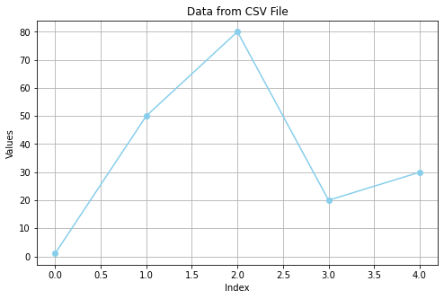

```python
import csv
import matplotlib.pyplot as plt
data = [
    ["Index", "Values"],  # Header row
    [1, 1],
    [2, 50],
    [3, 80],
    [4, 20],
    [5, 30]
]
file_name = "data.csv"
with open(file_name, "w", newline="") as file:
    writer = csv.writer(file)
    writer.writerows(data)

file_name = "data.csv"

column_name = "Values"

column_data = []
with open(file_name , "r") as file:
  csv_reader = csv.DictReader(file)
  for row in csv_reader:
    column_data.append(float(row[column_name]))

sum_values = sum(column_data)
print("Sum of values in column: ",sum_values)

plt.figure(figsize=(8,5))
plt.plot(column_data,marker='o',linestyle='-',color='skyblue')
plt.xlabel('Index')
plt.ylabel('Values')
plt.title('Data from CSV File')
plt.grid(True)
```

## 21)Write Python code to calculate:

```
Mean, median, mode, and standard deviation of a list of numbers.
Visualize the data using a box plot.
```

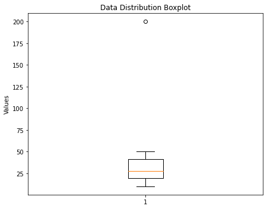

```
{'mean': 42.5, 'median': 27.5, 'mode': 10, 'standard_deviation': 48.932777017727766, 'variance': 2394.4166666666665, 'quartile_1': 19.5, 'quartile_3': 41.25, 'interquartile_range': 21.75, 'outliers': [200]}
```

```python
import numpy as np
import matplotlib.pyplot as plt
import statistics
from scipy import stats

def advanced_statistical_analysis(numbers):


    mean_value = np.mean(numbers)
    median_value = np.median(numbers)

    try:
        mode_value = statistics.mode(numbers)
    except statistics.StatisticsError:
        mode_value = "No unique mode"

    std_dev = np.std(numbers)
    variance = np.var(numbers)

    q1 = np.percentile(numbers, 25)
    q3 = np.percentile(numbers, 75)
    iqr = q3 - q1

    # Visualization
    plt.figure(figsize=(12, 5))

    # Box Plot
    plt.subplot(121)
    plt.boxplot(numbers, vert=True)
    plt.title('Data Distribution Boxplot')
    plt.ylabel('Values')



    plt.tight_layout()
    plt.show()

    # Outlier Detection
    z_scores = np.abs(stats.zscore(numbers))
    outliers = [num for num, z in zip(numbers, z_scores) if z > 3]

    return {
        'mean': mean_value,
        'median': median_value,
        'mode': mode_value,
        'standard_deviation': std_dev,
        'variance': variance,
        'quartile_1': q1,
        'quartile_3': q3,
        'interquartile_range': iqr,
        'outliers': outliers
    }

# Example Usage
sample_data = [10, 15, 20, 25, 30, 35, 40, 45, 50, 22, 18, 200]
result = advanced_statistical_analysis(sample_data)
print(result)
```

## 22)Write a Python function to normalize a list of numbers to a range of 0 to 1.Visualize the normalized data using a line plot.

```
Min-Max Normalization:
```

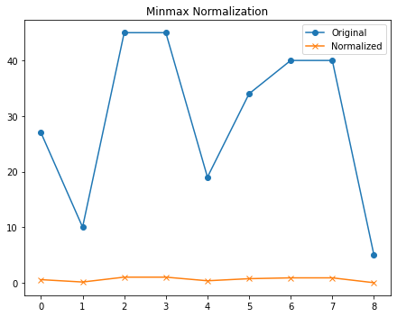

```
{'original_data': [27, 10, 45, 45, 19, 34, 40, 40, 5], 'normalized_data': array([0.55 , 0.125, 1.   , 1.   , 0.35 , 0.725, 0.875, 0.875, 0.   ]), 'min_value': 0.0, 'max_value': 1.0, 'method': 'minmax'}
```

```python
import numpy as np
import matplotlib.pyplot as plt


def normalize_data(numbers, method='minmax'):


    if method == 'minmax':
        normalized = (numbers - np.min(numbers)) / (np.max(numbers) - np.min(numbers))


    else:
        raise ValueError("Invalid normalization method")

    # Visualization
    plt.figure(figsize=(12, 5))

    # Original vs Normalized Line Plot
    plt.subplot(121)
    plt.plot(numbers, label='Original', marker='o')
    plt.plot(normalized, label='Normalized', marker='x')
    plt.title(f'{method.capitalize()} Normalization')
    plt.legend()



    plt.tight_layout()
    plt.show()

    return {
        'original_data': numbers,
        'normalized_data': normalized,
        'min_value': np.min(normalized),
        'max_value': np.max(normalized),
        'method': method
    }

# Example Usage
sample_data = [27, 10, 45, 45, 19, 34, 40, 40, 5]

# Different Normalization Methods
print("Min-Max Normalization:")
minmax_result = normalize_data(sample_data, method='minmax')
print(minmax_result)
```

## 23)Write a Python program that takes an integer input from the user and prints whether the number is even or odd.

```python
user_input = input('Enter an integer: ')
number = int(user_input)
if number%2 == 0:
  print(f"{number} is even")
else:
  print(f"{number} is odd")
```

```
Enter an integer: 48
48 is even
```

## 24)Write a Python program that takes a numerical grade (0-100) as input and prints the corresponding letter grade (A, B, C, D, F).

```python
grade = float(input("Enter numerical grade (0-100): "))

if 90 <= grade <= 100:
    letter_grade = 'A'
elif 80 <= grade < 90:
    letter_grade = 'B'
elif 70 <= grade < 80:
    letter_grade = 'C'
elif 60 <= grade < 70:
    letter_grade = 'D'
elif 0 <= grade < 60:
    letter_grade = 'F'
else:
    letter_grade = "Invalid input"

print(f"Your letter grade is: {letter_grade}")
```

```
Enter numerical grade (0-100): 89
Your letter grade is: B
```

## 25)Write a Python program that takes a year as input and checks if it is a leap yea

```python
def leapyearcheck(year):
    if (year % 4 == 0 and year % 100 != 0) or (year % 400 == 0):
        print(f"{year} is a leap year.")

    else:
        print(f"{year} is not a leap year.")


year = int(input("Enter a year: "))
leapyearcheck(year)
```

```
Enter a year: 78
78 is not a leap year.
```